# Comparisons between TEgenomeSimulator, denovoTE-eval, and Garlic

Ting-Hsuan Chen

16 October, 2026

## 1. TEgenomeSimulator vs denovoTEeval

### 1.01 The proportion of TE/nonTE sequence (mean ± SD, n = 5 replicates)

**Important:** denovoTE-eval doesn’t update simulated repeat.fa after nested insertion. So the TE bases calculated from its output repeat.fa doesn’t include nested TE insertion sequences. Need to calculate TE bases from TE gff file.

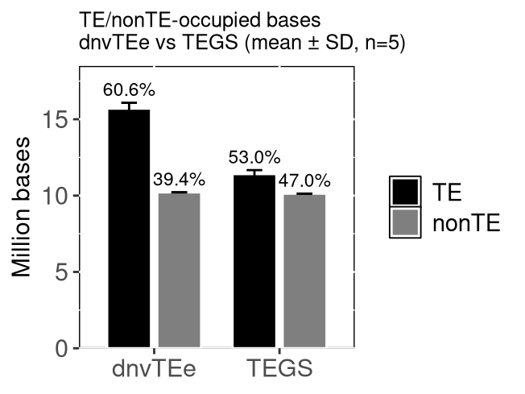

### 1.02 TE composition

| TE_superfamily | loci | bp | family_count | loci_percentage | bp_percentage | family_percentage |
| --- | --- | --- | --- | --- | --- | --- |
| DNA/CACTA | 603 | 1219033 | 110 | 6.79 | 10.30 | 6.79 |
| DNA/Harbinger | 17 | 26776 | 3 | 0.19 | 0.23 | 0.19 |
| DNA/hAT | 1410 | 842156 | 249 | 15.88 | 7.12 | 15.37 |
| DNA/Mariner | 33 | 10883 | 7 | 0.37 | 0.09 | 0.43 |
| DNA/MULE | 2138 | 3328305 | 393 | 24.08 | 28.13 | 24.26 |
| LINE/L1 | 66 | 164530 | 12 | 0.74 | 1.39 | 0.74 |
| LINE/unknown | 562 | 790215 | 94 | 6.33 | 6.68 | 5.80 |
| LTR/Copia | 594 | 1310911 | 117 | 6.69 | 11.08 | 7.22 |
| LTR/Solo | 11 | 8805 | 3 | 0.12 | 0.07 | 0.19 |
| LTR/Ty3 | 561 | 1419888 | 104 | 6.32 | 12.00 | 6.42 |
| LTR/unknown | 61 | 55773 | 11 | 0.69 | 0.47 | 0.68 |
| MITE/Stow | 175 | 22685 | 40 | 1.97 | 0.19 | 2.47 |
| MITE/Tourist | 669 | 98042 | 115 | 7.54 | 0.83 | 7.10 |
| RC/Helitron | 1730 | 2446288 | 314 | 19.49 | 20.68 | 19.38 |
| SINE/tRNA | 25 | 3726 | 5 | 0.28 | 0.03 | 0.31 |
| SINE/unknown | 222 | 82903 | 43 | 2.50 | 0.70 | 2.65 |
| Total | 8877 | 11830919 | 1620 | 100.00 | 100.00 | 100.00 |

| TE_superfamily | loci | bp | family_count | loci_percentage | bp_percentage | family_percentage |
| --- | --- | --- | --- | --- | --- | --- |
| DNA/CACTA | 628 | 1601286 | 110 | 6.99 | 9.90 | 6.76 |
| DNA/Harbinger | 27 | 64496 | 3 | 0.30 | 0.40 | 0.18 |
| DNA/hAT | 1435 | 1223043 | 249 | 15.97 | 7.56 | 15.29 |
| DNA/Mariner | 43 | 23522 | 7 | 0.48 | 0.15 | 0.43 |
| DNA/MULE | 2176 | 4305043 | 393 | 24.22 | 26.61 | 24.14 |
| LINE/L1 | 73 | 257460 | 12 | 0.81 | 1.59 | 0.74 |
| LINE/unknown | 501 | 978868 | 94 | 5.58 | 6.05 | 5.77 |
| LTR/Copia | 655 | 2001542 | 126 | 7.29 | 12.37 | 7.74 |
| LTR/Solo | 20 | 23622 | 3 | 0.22 | 0.15 | 0.18 |
| LTR/Ty3 | 592 | 1886636 | 103 | 6.59 | 11.66 | 6.33 |
| LTR/unknown | 60 | 89378 | 11 | 0.67 | 0.55 | 0.68 |
| MITE/Stow | 206 | 41469 | 40 | 2.29 | 0.26 | 2.46 |
| MITE/Tourist | 631 | 146269 | 115 | 7.02 | 0.90 | 7.06 |
| RC/Helitron | 1704 | 3433058 | 314 | 18.96 | 21.22 | 19.29 |
| SINE/tRNA | 27 | 5517 | 5 | 0.30 | 0.03 | 0.31 |
| SINE/unknown | 207 | 94603 | 43 | 2.30 | 0.58 | 2.64 |
| Total | 8985 | 16175812 | 1620 | 100.00 | 100.00 | 100.00 |

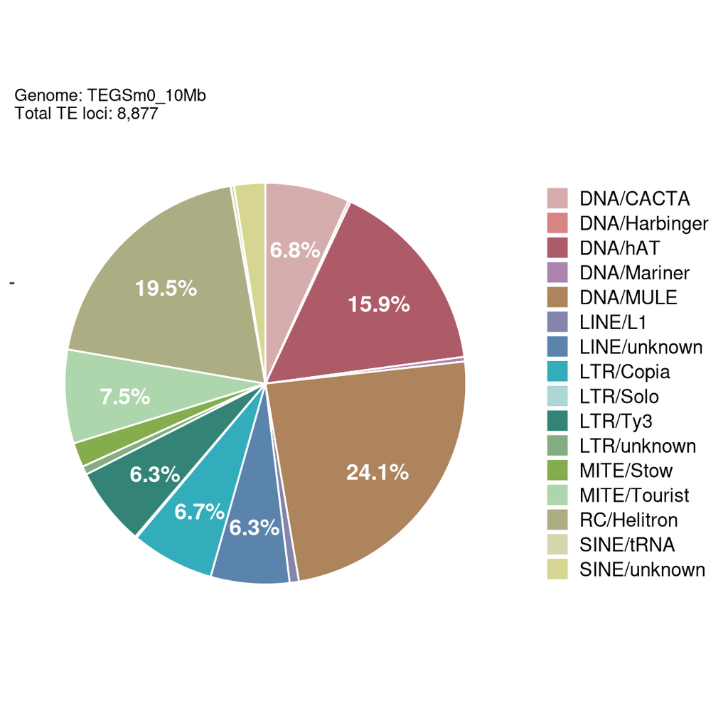

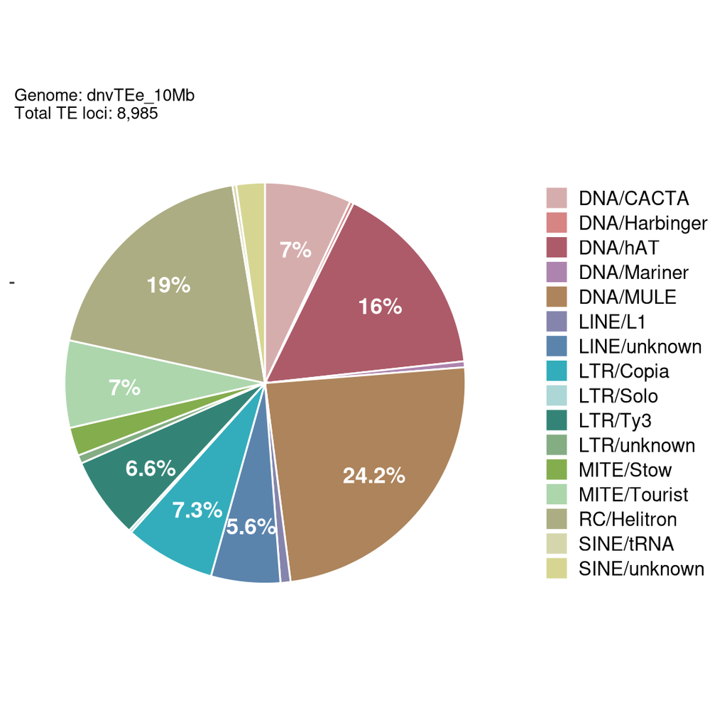

#### Mean ± SD across 5 replicates, dodged by superfamily

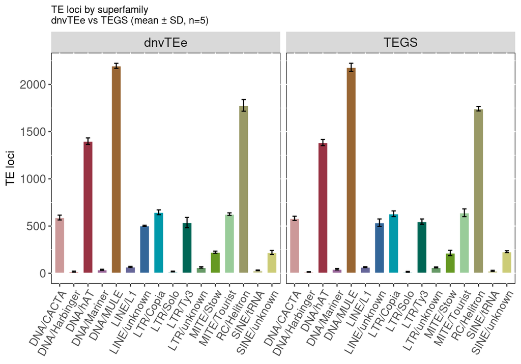

### 1.03 Total simulated TE bases categorised by TE superfamily

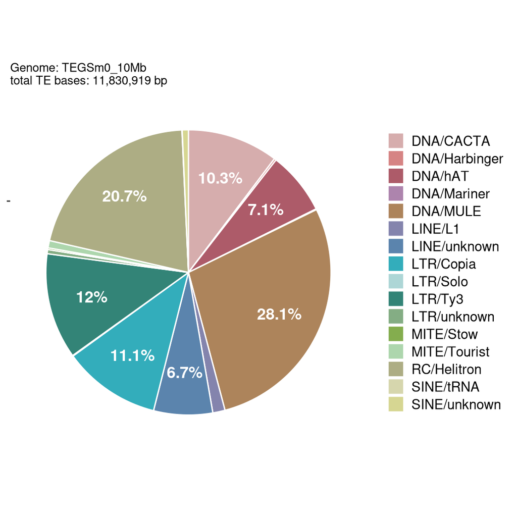

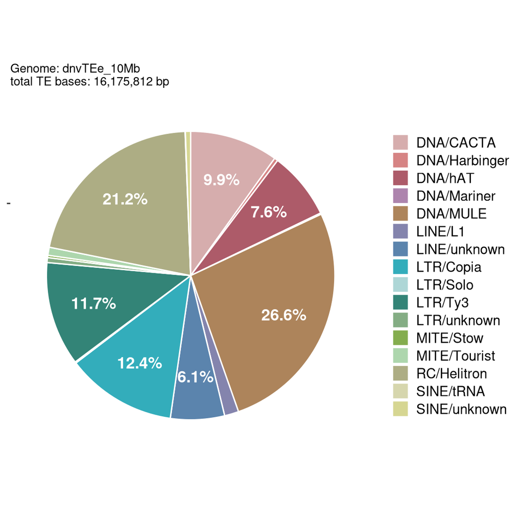

#### Mean ± SD across 5 replicates, dodged by superfamily

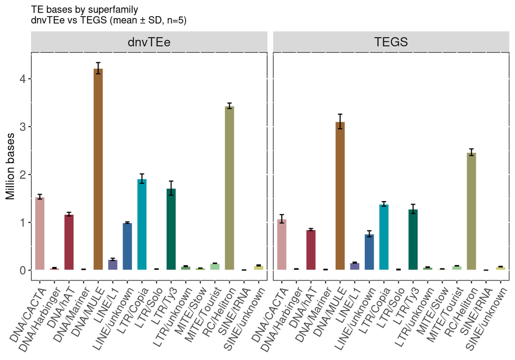

### 1.04 The distribution of TE loci divergence

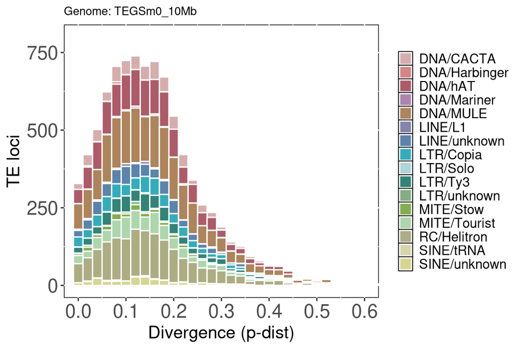

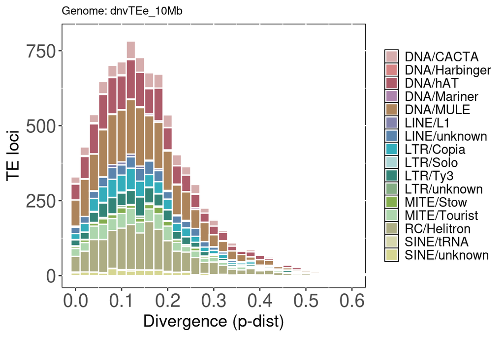

#### Supplementary: per-replicate view, colored by TE superfamily (n = 5 replicates each)

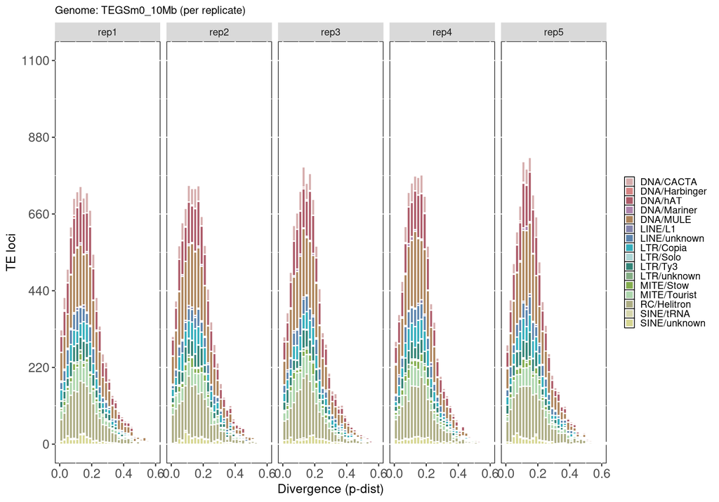

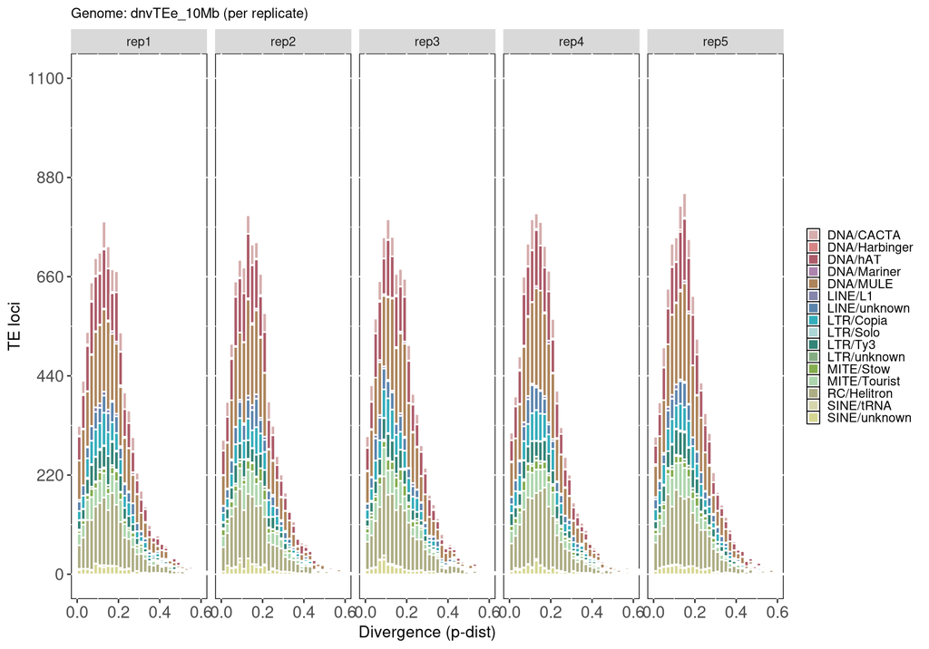

#### Supplementary: simulator-reported vs RepeatMasker-detected vs post-fix divergence

Three per-locus divergence distributions are compared for each simulator:

- **Reported**: `div = 1 - Identity` from the simulator’s GFF (`breakdown*_allreps`).
- **RepeatMasker**: `mismatch` from TEgenomeSimulator’s `te_scan_only` post-simulation detection (`processed_output.temp`), i.e. (substitutions + insertions + deletions) / aligned length from the RepeatMasker `.out`. The simulator’s reported divergence is defined the same way (substitutions and indels), so the two are directly comparable. All rows are used (no filtering).
- **Post-fix**: divergence implied by the corrected identity `identity + (1 - identity) * 0.5` (fraction scale), i.e. `0.5 * div`.

Histograms use replicate 1; the Wasserstein comparison uses all 5 replicates.

| simulator | source | rep | n | mean | median | sd |
| --- | --- | --- | --- | --- | --- | --- |
| TEGS | Reported | 1 | 8877 | 0.1611 | 0.150 | 0.1056 |
| TEGS | Reported | 2 | 8963 | 0.1598 | 0.150 | 0.1033 |
| TEGS | Reported | 3 | 8953 | 0.1623 | 0.150 | 0.1045 |
| TEGS | Reported | 4 | 8822 | 0.1588 | 0.150 | 0.1007 |
| TEGS | Reported | 5 | 8940 | 0.1601 | 0.140 | 0.1041 |
| TEGS | RepeatMasker | 1 | 7439 | 0.1358 | 0.127 | 0.0834 |
| TEGS | RepeatMasker | 2 | 7557 | 0.1367 | 0.129 | 0.0828 |
| TEGS | RepeatMasker | 3 | 7522 | 0.1376 | 0.129 | 0.0826 |
| TEGS | RepeatMasker | 4 | 7447 | 0.1352 | 0.128 | 0.0795 |
| TEGS | RepeatMasker | 5 | 7462 | 0.1353 | 0.126 | 0.0818 |
| TEGS | Post-fix | 1 | 8877 | 0.0805 | 0.075 | 0.0528 |
| TEGS | Post-fix | 2 | 8963 | 0.0799 | 0.075 | 0.0517 |
| TEGS | Post-fix | 3 | 8953 | 0.0812 | 0.075 | 0.0522 |
| TEGS | Post-fix | 4 | 8822 | 0.0794 | 0.075 | 0.0504 |
| TEGS | Post-fix | 5 | 8940 | 0.0801 | 0.070 | 0.0520 |
| dnvTEe | Reported | 1 | 8985 | 0.1611 | 0.150 | 0.1063 |
| dnvTEe | Reported | 2 | 8799 | 0.1601 | 0.150 | 0.1035 |
| dnvTEe | Reported | 3 | 8914 | 0.1591 | 0.140 | 0.1050 |
| dnvTEe | Reported | 4 | 8980 | 0.1583 | 0.140 | 0.1022 |
| dnvTEe | Reported | 5 | 9083 | 0.1608 | 0.140 | 0.1025 |
| dnvTEe | RepeatMasker | 1 | 8987 | 0.0761 | 0.068 | 0.0511 |
| dnvTEe | RepeatMasker | 2 | 8800 | 0.0757 | 0.069 | 0.0496 |
| dnvTEe | RepeatMasker | 3 | 8902 | 0.0750 | 0.066 | 0.0501 |
| dnvTEe | RepeatMasker | 4 | 8979 | 0.0748 | 0.067 | 0.0487 |
| dnvTEe | RepeatMasker | 5 | 9074 | 0.0756 | 0.068 | 0.0484 |
| dnvTEe | Post-fix | 1 | 8985 | 0.0805 | 0.075 | 0.0531 |
| dnvTEe | Post-fix | 2 | 8799 | 0.0800 | 0.075 | 0.0518 |
| dnvTEe | Post-fix | 3 | 8914 | 0.0795 | 0.070 | 0.0525 |
| dnvTEe | Post-fix | 4 | 8980 | 0.0791 | 0.070 | 0.0511 |
| dnvTEe | Post-fix | 5 | 9083 | 0.0804 | 0.070 | 0.0512 |

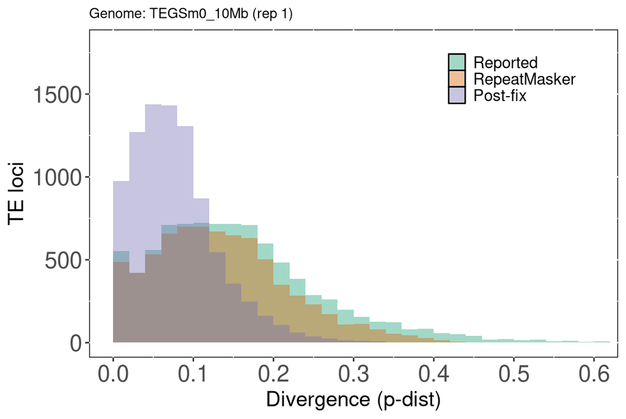

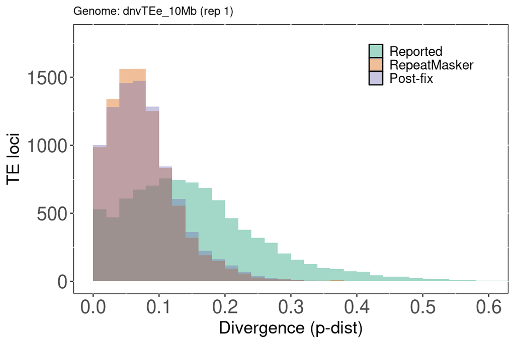

Per replicate, the 1D Wasserstein distance is computed between each pair of the three distributions. For each simulator, W(Reported, RepeatMasker) and W(Post-fix, RepeatMasker) are compared with a paired t-test across the 5 replicates (paired because both distances in a replicate share the same RepeatMasker sample); a lower distance means closer to what RepeatMasker detects.

| simulator | pair | n | mean_wasserstein | sd_wasserstein |
| --- | --- | --- | --- | --- |
| TEGS | Reported vs RepeatMasker | 5 | 0.0243 | 9e-04 |
| TEGS | Post-fix vs RepeatMasker | 5 | 0.0560 | 7e-04 |
| TEGS | Reported vs Post-fix | 5 | 0.0802 | 7e-04 |
| dnvTEe | Reported vs RepeatMasker | 5 | 0.0844 | 7e-04 |
| dnvTEe | Post-fix vs RepeatMasker | 5 | 0.0046 | 2e-04 |
| dnvTEe | Reported vs Post-fix | 5 | 0.0799 | 6e-04 |

| comparison | test_type | n1 | n2 | mean1 | mean2 | reference | mean_diff | t_statistic | df | p_value | conf_low | conf_high | alternative | simulator | group1 | group2 |
| --- | --- | --- | --- | --- | --- | --- | --- | --- | --- | --- | --- | --- | --- | --- | --- | --- |
| TEGS: W(Reported, RM) vs W(Post-fix, RM) | paired t-test (by replicate) | 5 | 5 | 0.0243 | 0.0560 | NA | -0.0317 | -47.9446 | 4 | 0 | -0.0335 | -0.0299 | two.sided | TEGS | Reported vs RepeatMasker | Post-fix vs RepeatMasker |
| dnvTEe: W(Reported, RM) vs W(Post-fix, RM) | paired t-test (by replicate) | 5 | 5 | 0.0844 | 0.0046 | NA | 0.0798 | 315.2552 | 4 | 0 | 0.0791 | 0.0805 | two.sided | dnvTEe | Reported vs RepeatMasker | Post-fix vs RepeatMasker |

Files saved as: wasserstein_div_reported_rm_postfix_per_replicate.tsv, wasserstein_div_reported_rm_postfix_meansd.tsv, wasserstein_div_reported_rm_postfix_ttest.tsv

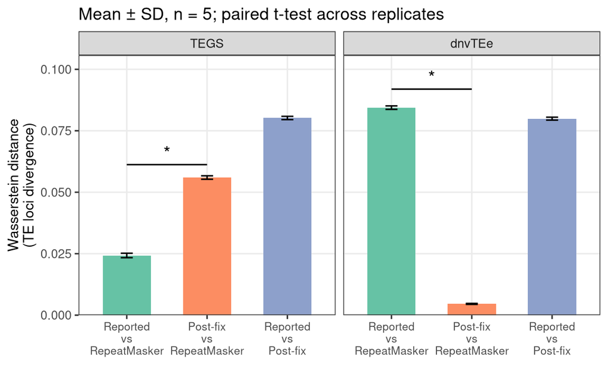

#### Mean ± SD across 5 replicates (superfamilies pooled)

Bin mean/SD are extracted directly from the built histograms above via `ggplot_build()` (`summarise_bins_from_histogram()`), rather than recomputed independently with `cut()` - this guarantees the line graph and the histogram always agree on bin position/width/side.

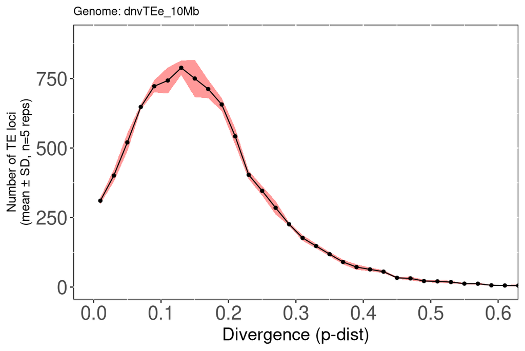

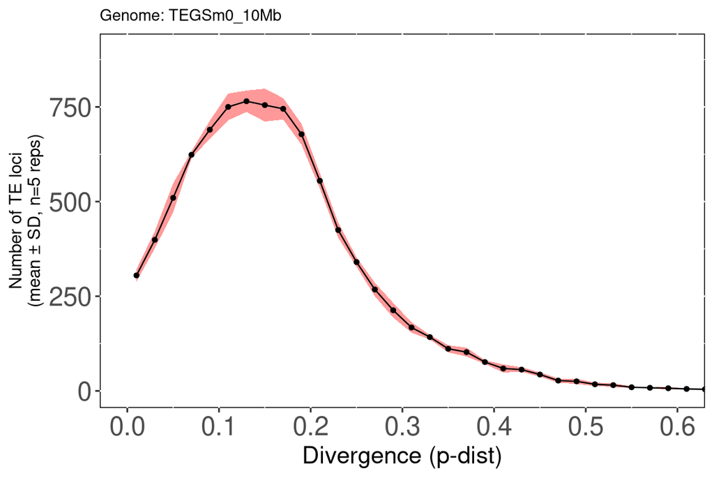

### 1.05 The distribution of TE loci integrity

#### Supplementary: per-replicate view, colored by TE superfamily (n = 5 replicates each)

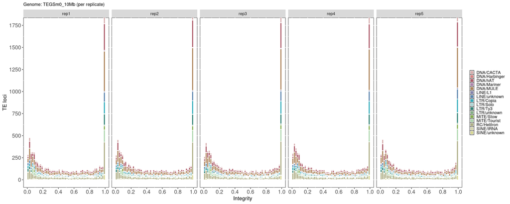

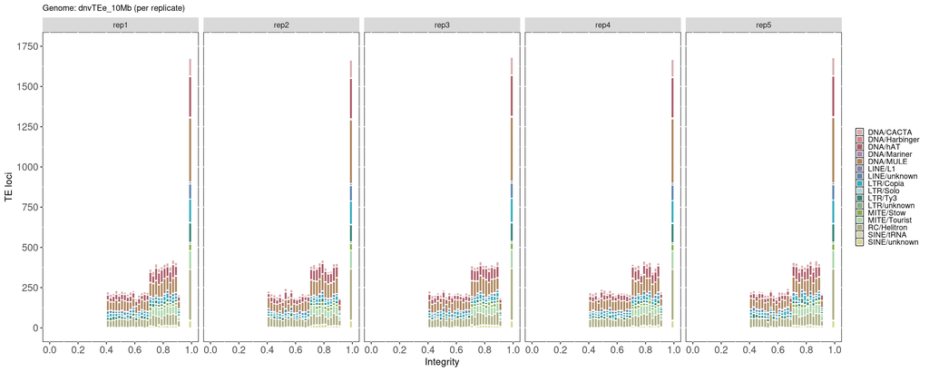

Fragment setting in denovoTE-eval:

```
def fragment (seq):
    frag_size = 100
    len_seq =len(seq)
    if len_seq < 500:
        frag_size = random.randint(70,90)
    else:
        frag_size = random.randint(40,90)
    cut_length = int(len_seq*((100 - frag_size)/100.0))
    return seq[cut_length:], frag_size, cut_length
```

#### Figure 2 E/F: TE loci integrity distribution, mean ± SD across 5 replicates (superfamilies pooled)

Bin mean/SD are extracted directly from the built histograms above via `ggplot_build()` (`summarise_bins_from_histogram()`), rather than recomputed independently with `cut()` - this guarantees the line graph and the histogram always agree on bin position/width/side.

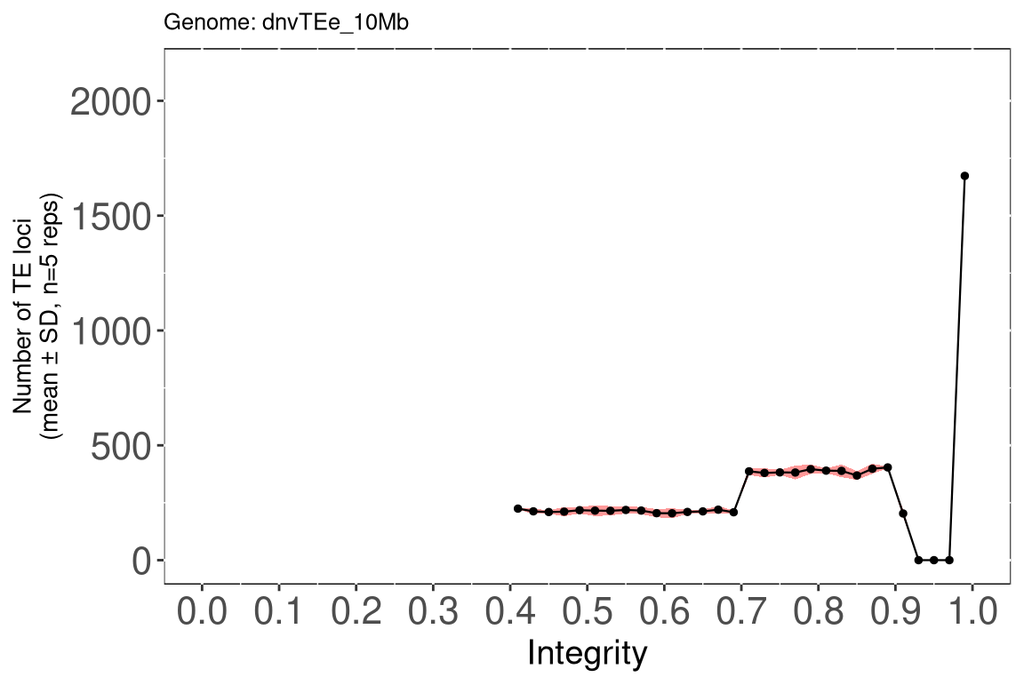

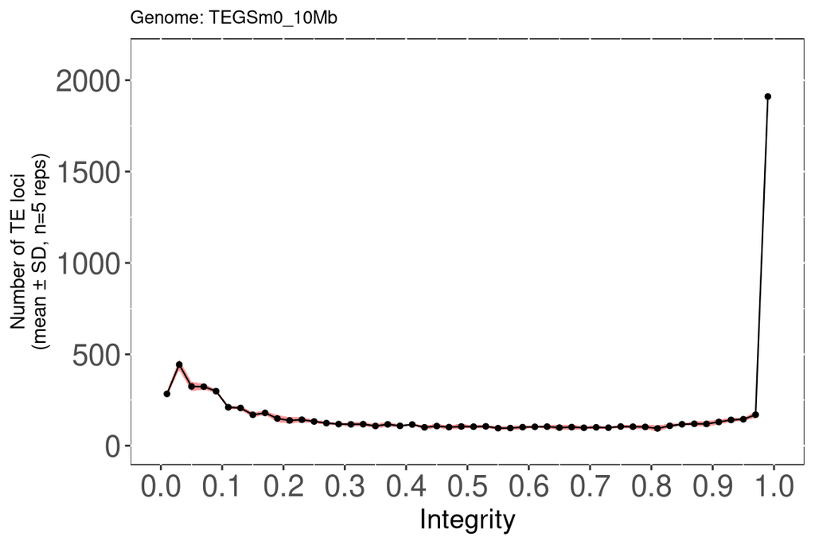

## 2. TEgenomeSimulator vs Garlic

### 2.01 The proportion of the TE/nonTE sequence (mean ± SD, n = 5 replicates for m2, m2+m0, Garlic; Original genome not replicated)

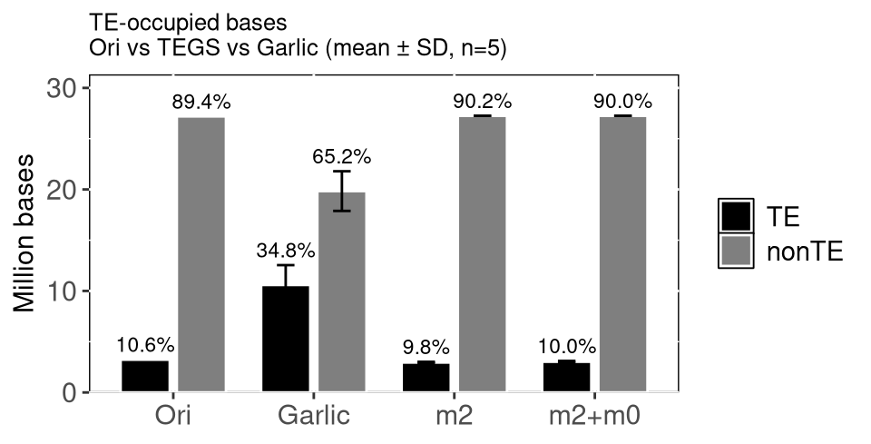

### 2.01a t-test on simulated TE bases (n = 5 replicates)

Compares total simulated TE bases (`tesize`) between simulators. dnvTEe vs TEGS is a two-sample Welch t-test (5 replicates each). Garlic/m2/m2+m0 vs Ori are one-sample t-tests against Ori’s single fixed value, since the original genome is not replicated.

| comparison | test_type | n1 | n2 | mean1_bases | mean2_bases | reference_bases | mean_diff_bases | t_statistic | df | p_value | conf_low | conf_high | alternative |
| --- | --- | --- | --- | --- | --- | --- | --- | --- | --- | --- | --- | --- | --- |
| dnvTEe vs TEGS | two-sample t-test (Welch) | 5 | 5 | 15697290 | 11409601 | NA | 4287688.6 | 20.8188 | 7.0405 | 0.0000 | 3801255.3 | 4774121.89 | two.sided |
| GARLIC vs Ori | one-sample t-test (vs fixed Ori value) | 5 | NA | 10589415 | NA | 3231994 | 7357420.8 | 8.4207 | 4.0000 | 0.0011 | 8163564.6 | 13015265.04 | two.sided |
| m2 vs Ori | one-sample t-test (vs fixed Ori value) | 5 | NA | 2951864 | NA | 3231994 | -280130.0 | -9.5337 | 4.0000 | 0.0007 | 2870283.6 | 3033444.37 | two.sided |
| m2+m0 vs Ori | one-sample t-test (vs fixed Ori value) | 5 | NA | 3030615 | NA | 3231994 | -201378.8 | -5.6609 | 4.0000 | 0.0048 | 2931846.9 | 3129383.48 | two.sided |
| GARLIC vs m2 | two-sample t-test (Welch) | 5 | 5 | 10589415 | 2951864 | NA | 7637550.8 | 8.7364 | 4.0090 | 0.0009 | 5212488.0 | 10062613.62 | two.sided |
| GARLIC vs m2+m0 | two-sample t-test (Welch) | 5 | 5 | 10589415 | 3030615 | NA | 7558799.6 | 8.6441 | 4.0133 | 0.0010 | 5134100.3 | 9983498.94 | two.sided |
| m2 vs m2+m0 | two-sample t-test (Welch) | 5 | 5 | 2951864 | 3030615 | NA | -78751.2 | -1.7068 | 7.7244 | 0.1276 | -185813.3 | 28310.94 | two.sided |

File saved as: tebases_ttest_results.tsv

### 2.02 TE composition

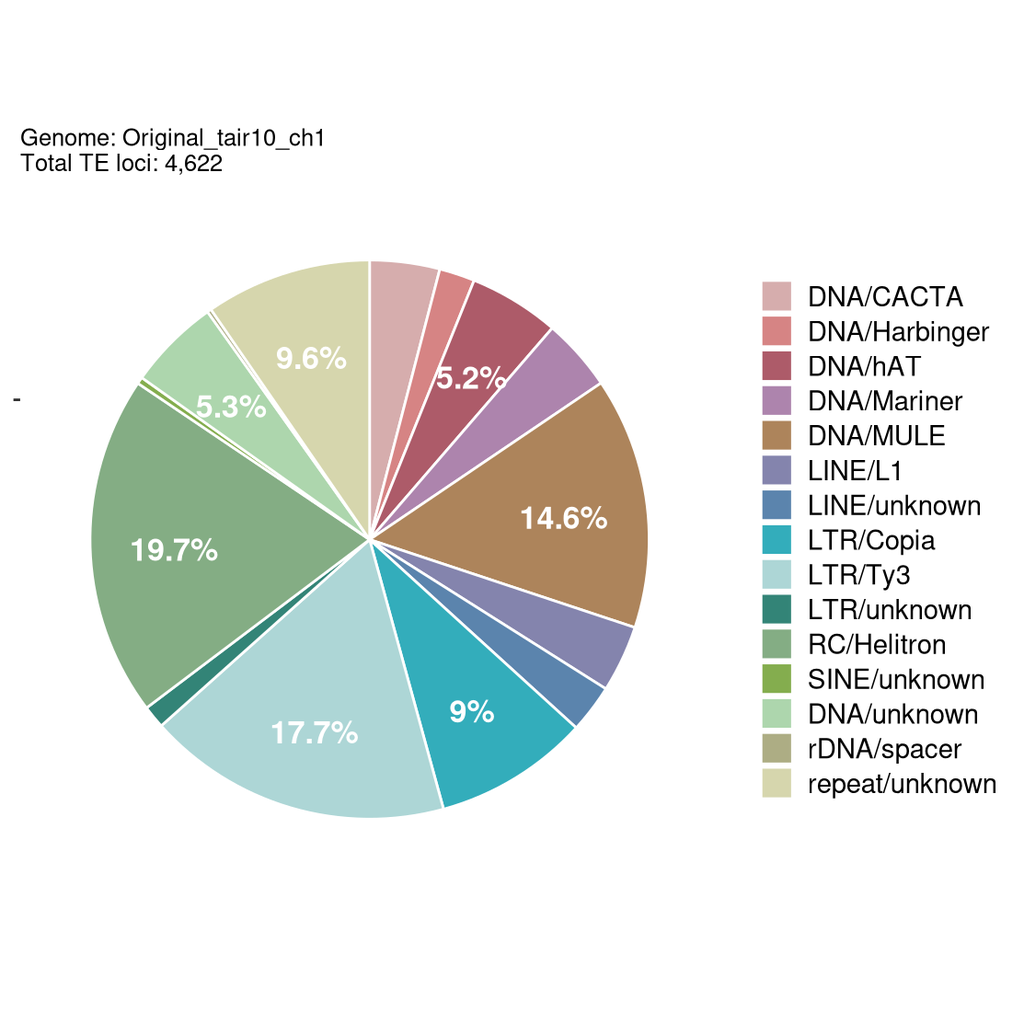

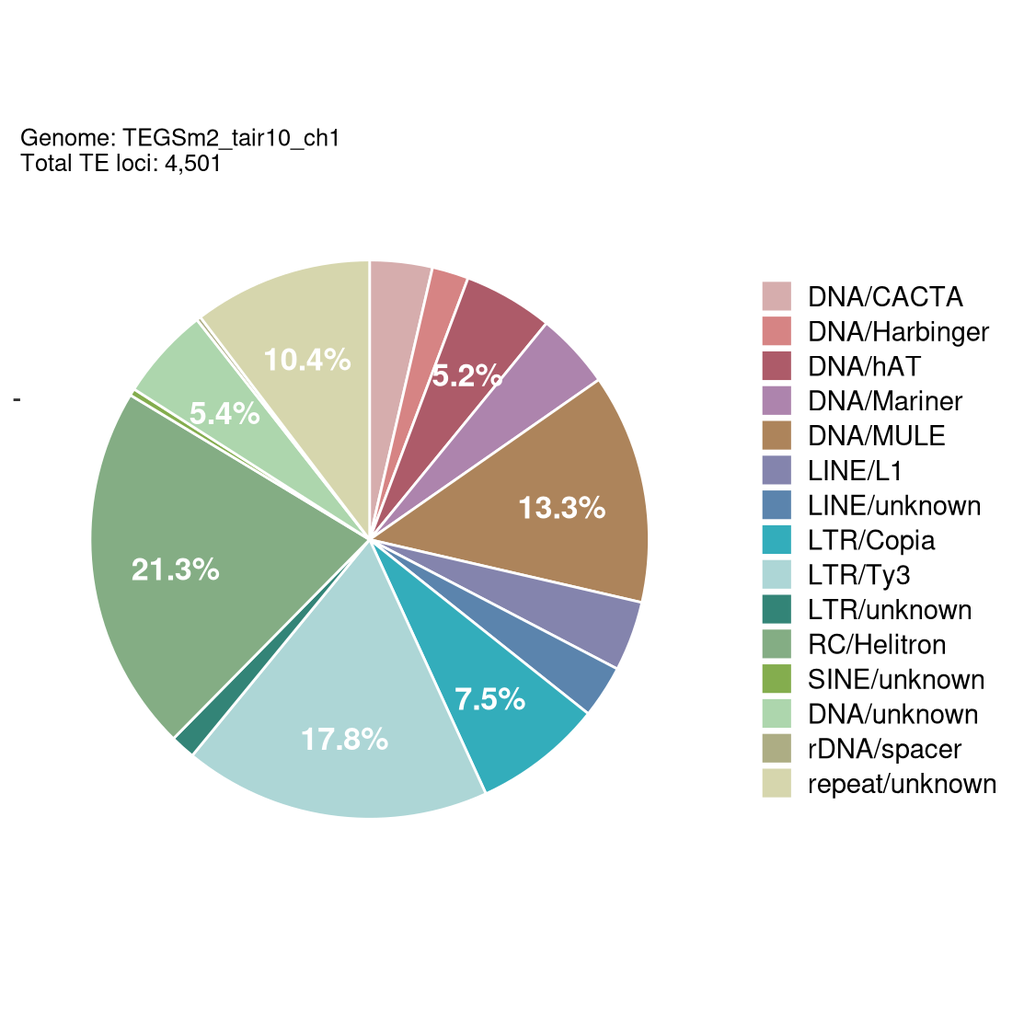

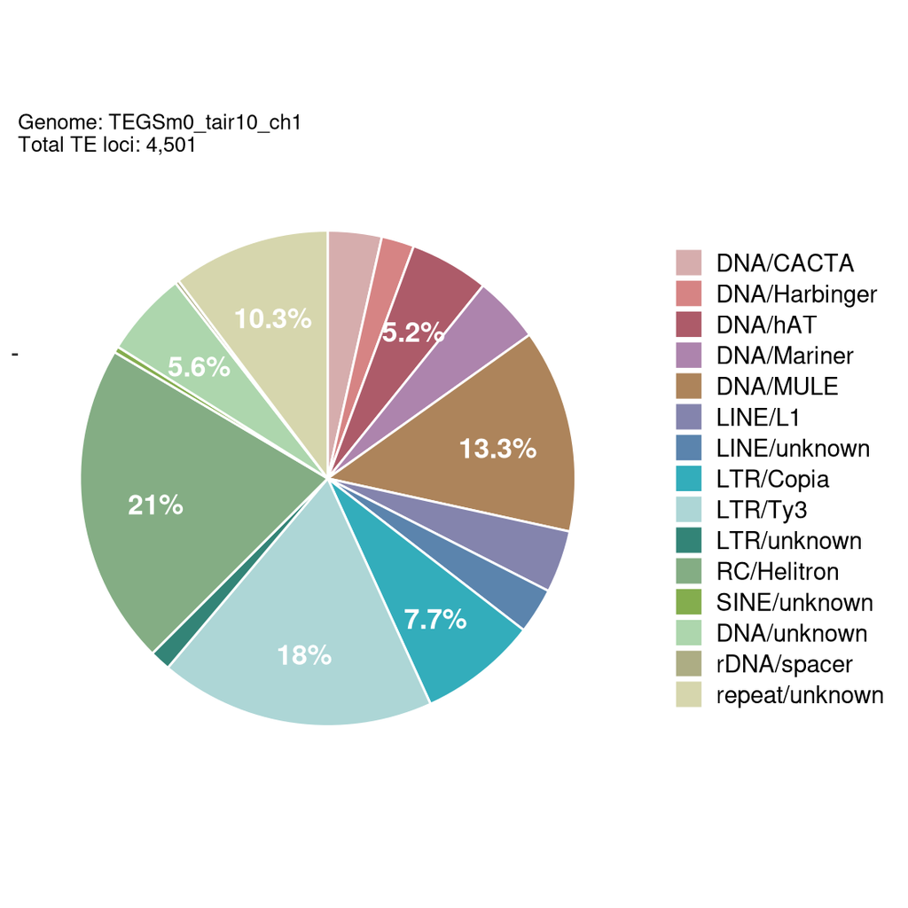

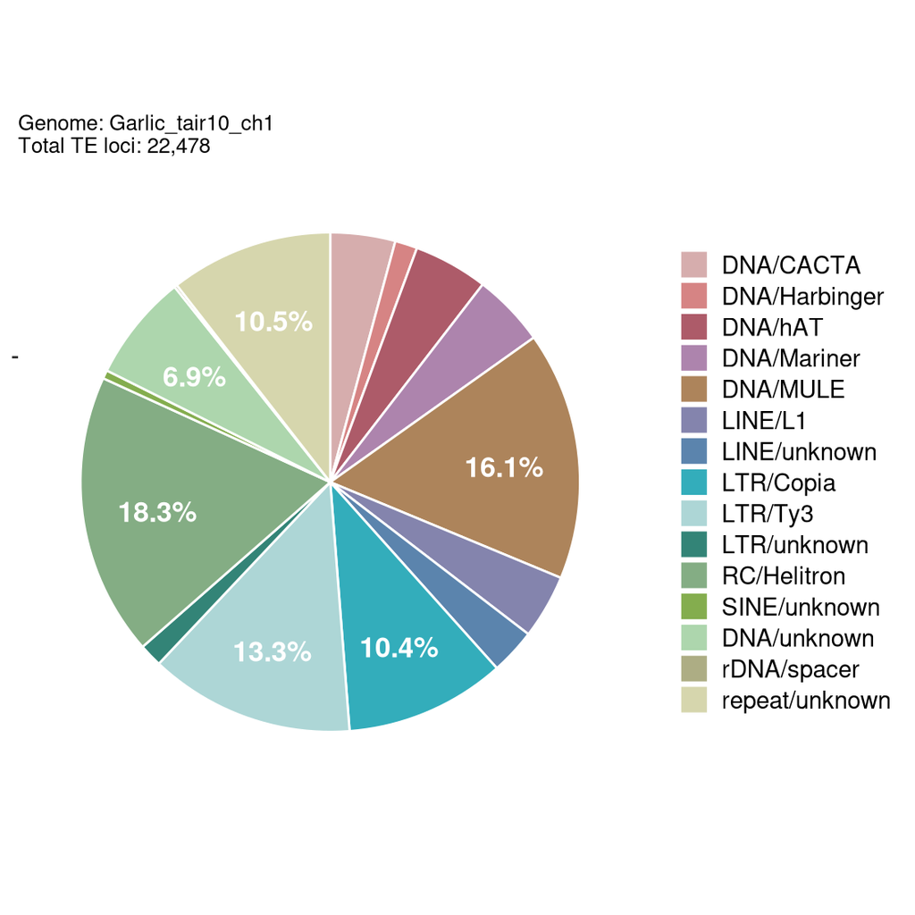

#### Mean ± SD across replicates, dodged by superfamily (Ori not replicated)

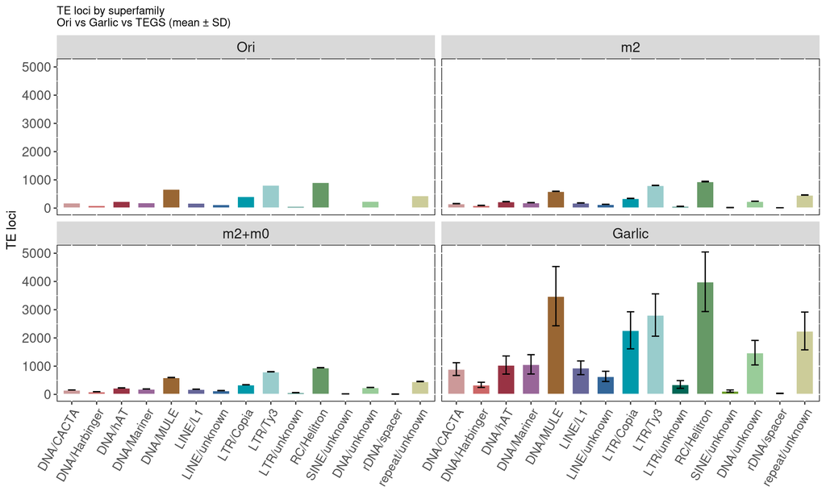

### 2.03 Total simulated TE bases categorised by TE superfamily

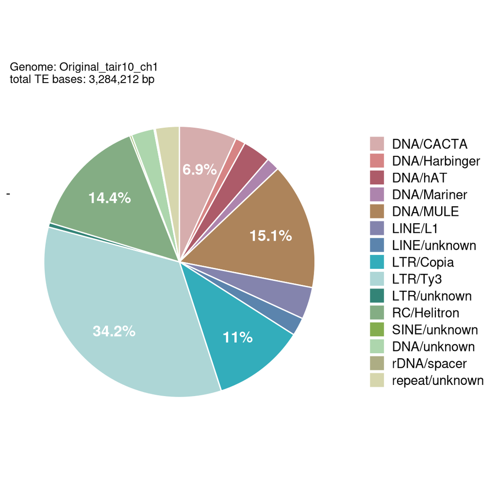

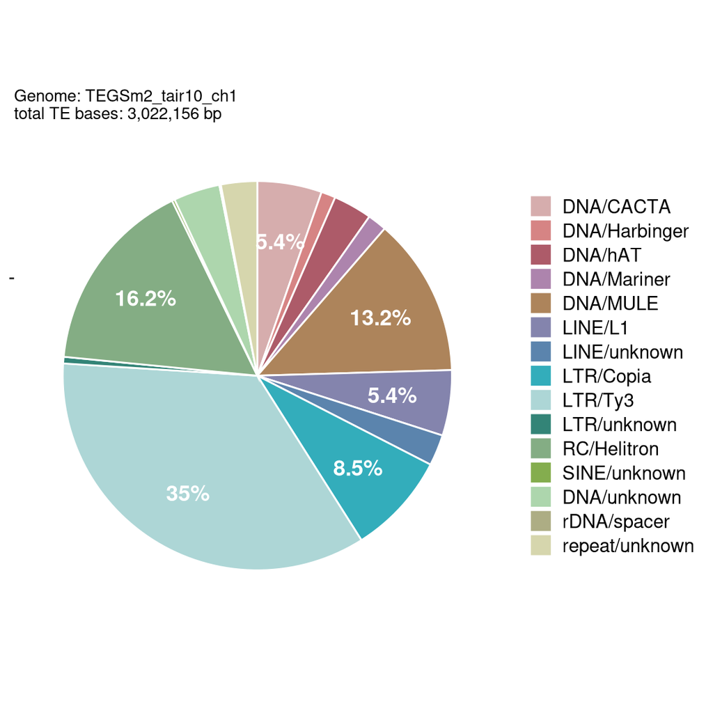

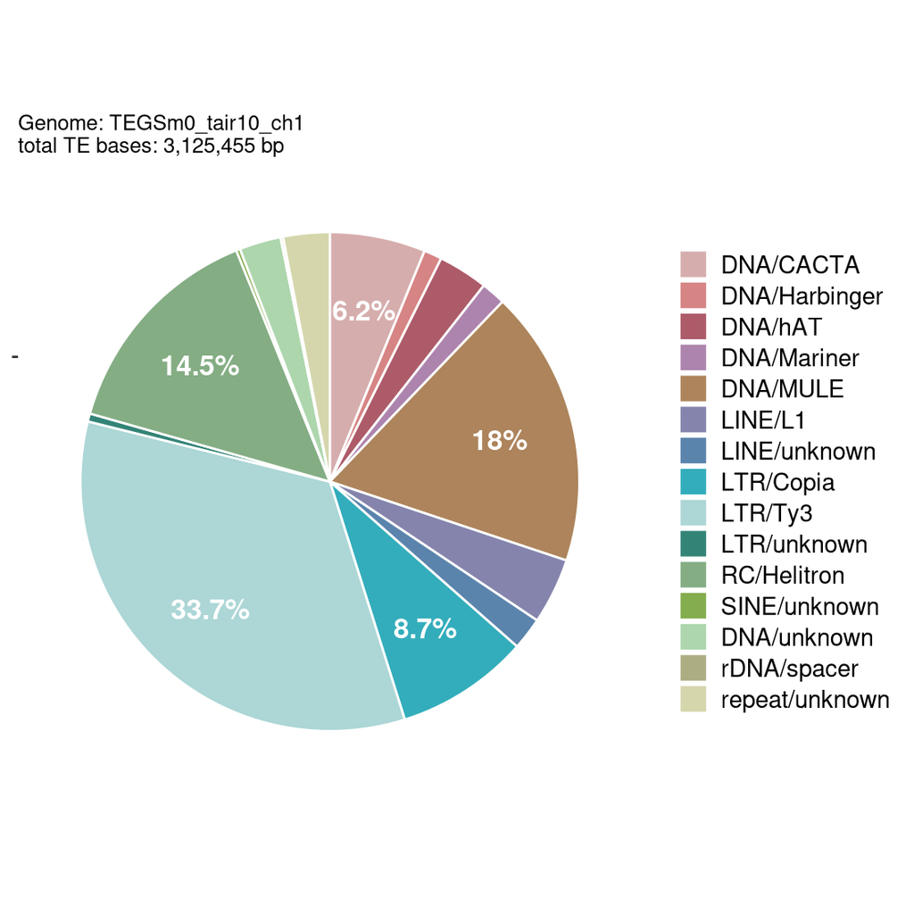

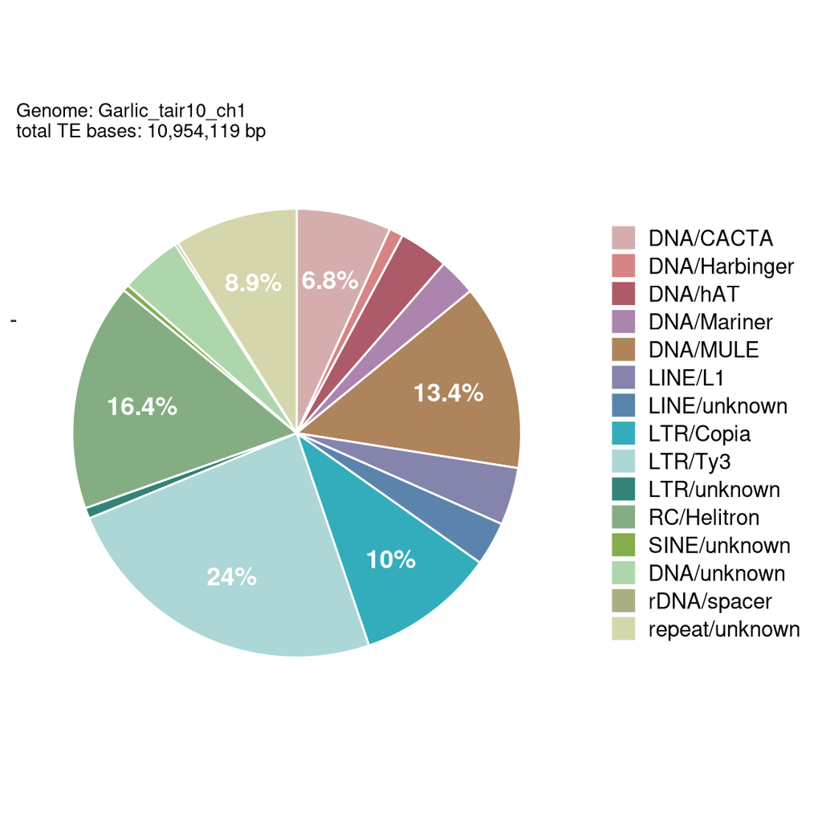

#### Mean ± SD across replicates, dodged by superfamily (Ori not replicated)

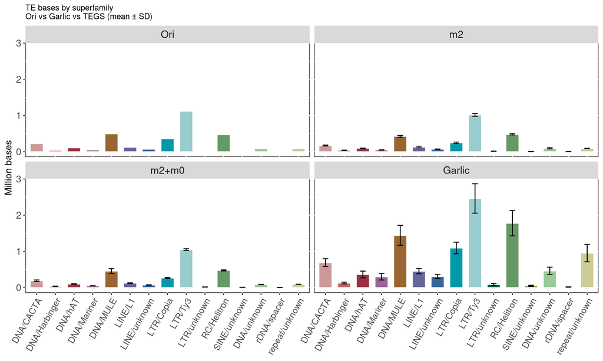

### 2.03a Jensen-Shannon divergence: TE composition by superfamily (per replicate)

Categorical distribution of TE bases and TE loci counts across superfamilies (as in panels 1.02/1.03/2.02/2.03), compared per replicate for both metrics. dnvTEe vs TEGS uses matched replicate pairs (rep i’s dnvTEe run reuses rep i’s TEGS composition table). Garlic/m2/m2+m0 vs Ori compares each replicate to Ori’s single fixed distribution (the real chr1 is not replicated). Superfamily categories present in only one side of a comparison are zero-filled, not dropped, so JSD is always computed over the full union of categories.

| comparison | rep | metric | jsd |
| --- | --- | --- | --- |
| dnvTEe vs TEGS | 1 | bp | 0.0011 |
| dnvTEe vs TEGS | 2 | bp | 0.0006 |
| dnvTEe vs TEGS | 3 | bp | 0.0005 |
| dnvTEe vs TEGS | 4 | bp | 0.0008 |
| dnvTEe vs TEGS | 5 | bp | 0.0004 |
| GARLIC vs Ori | 1 | bp | 0.0230 |
| GARLIC vs Ori | 2 | bp | 0.0262 |
| GARLIC vs Ori | 3 | bp | 0.0195 |
| GARLIC vs Ori | 4 | bp | 0.0313 |
| GARLIC vs Ori | 5 | bp | 0.0214 |
| m2 vs Ori | 1 | bp | 0.0047 |
| m2 vs Ori | 2 | bp | 0.0022 |
| m2 vs Ori | 3 | bp | 0.0027 |
| m2 vs Ori | 4 | bp | 0.0025 |
| m2 vs Ori | 5 | bp | 0.0032 |
| m2+m0 vs Ori | 1 | bp | 0.0021 |
| m2+m0 vs Ori | 2 | bp | 0.0010 |
| m2+m0 vs Ori | 3 | bp | 0.0032 |
| m2+m0 vs Ori | 4 | bp | 0.0014 |
| m2+m0 vs Ori | 5 | bp | 0.0025 |
| dnvTEe vs TEGS | 1 | count | 0.0008 |
| dnvTEe vs TEGS | 2 | count | 0.0006 |
| dnvTEe vs TEGS | 3 | count | 0.0007 |
| dnvTEe vs TEGS | 4 | count | 0.0009 |
| dnvTEe vs TEGS | 5 | count | 0.0003 |
| GARLIC vs Ori | 1 | count | 0.0048 |
| GARLIC vs Ori | 2 | count | 0.0055 |
| GARLIC vs Ori | 3 | count | 0.0045 |
| GARLIC vs Ori | 4 | count | 0.0066 |
| GARLIC vs Ori | 5 | count | 0.0042 |
| m2 vs Ori | 1 | count | 0.0012 |
| m2 vs Ori | 2 | count | 0.0010 |
| m2 vs Ori | 3 | count | 0.0011 |
| m2 vs Ori | 4 | count | 0.0010 |
| m2 vs Ori | 5 | count | 0.0011 |
| m2+m0 vs Ori | 1 | count | 0.0010 |
| m2+m0 vs Ori | 2 | count | 0.0013 |
| m2+m0 vs Ori | 3 | count | 0.0011 |
| m2+m0 vs Ori | 4 | count | 0.0010 |
| m2+m0 vs Ori | 5 | count | 0.0010 |

File saved as: jsd_superfamily_per_replicate.tsv (columns: comparison, rep, metric [“bp”/“count”], jsd)

### 2.03b Superfamily-composition JSD: mean ± SD and significance testing

Mean ± SD summarised per comparison and metric. Significance testing follows the replicate design of each comparison: dnvTEe vs TEGS is matched-pair by construction, so its 5 JSD values (one per matched rep pair) are tested with a one-sample t-test against mu = 0 (is the divergence between the two tools significantly non-zero, despite matched input tables?). Garlic, m2, and m2+m0 replicates were each generated independently of one another (no shared seed or composition table linking, say, Garlic rep 3 to m2 rep 3), so their JSD-to-Ori values are compared pairwise with unpaired (two-sample Welch) t-tests instead, to test which tool sits significantly closer to Ori.

| comparison | metric | n | mean_jsd | sd_jsd |
| --- | --- | --- | --- | --- |
| GARLIC vs Ori | bp | 5 | 0.0243 | 0.0047 |
| GARLIC vs Ori | count | 5 | 0.0051 | 0.0010 |
| dnvTEe vs TEGS | bp | 5 | 0.0007 | 0.0003 |
| dnvTEe vs TEGS | count | 5 | 0.0006 | 0.0002 |
| m2 vs Ori | bp | 5 | 0.0030 | 0.0010 |
| m2 vs Ori | count | 5 | 0.0011 | 0.0001 |
| m2+m0 vs Ori | bp | 5 | 0.0020 | 0.0009 |
| m2+m0 vs Ori | count | 5 | 0.0011 | 0.0001 |

| comparison | test_type | n1 | n2 | mean1 | mean2 | reference | mean_diff | t_statistic | df | p_value | conf_low | conf_high | alternative | metric | group1 | group2 |
| --- | --- | --- | --- | --- | --- | --- | --- | --- | --- | --- | --- | --- | --- | --- | --- | --- |
| dnvTEe vs TEGS (superfamily JSD, bp) | one-sample t-test (vs mu) | 5 | NA | 0.0007 | NA | 0 | 0.0007 | 5.6939 | 4.0000 | 0.0047 | 0.0004 | 0.0010 | two.sided | bp | dnvTEe vs TEGS | NA |
| GARLIC vs m2 (distance-to-Ori superfamily JSD, bp) | two-sample t-test (Welch, unpaired) | 5 | 5 | 0.0243 | 0.0030 | NA | 0.0213 | 9.9827 | 4.3528 | 0.0004 | 0.0155 | 0.0270 | two.sided | bp | GARLIC vs Ori | m2 vs Ori |
| GARLIC vs m2+m0 (distance-to-Ori superfamily JSD, bp) | two-sample t-test (Welch, unpaired) | 5 | 5 | 0.0243 | 0.0020 | NA | 0.0223 | 10.4973 | 4.2776 | 0.0003 | 0.0165 | 0.0280 | two.sided | bp | GARLIC vs Ori | m2+m0 vs Ori |
| m2 vs m2+m0 (distance-to-Ori superfamily JSD, bp) | two-sample t-test (Welch, unpaired) | 5 | 5 | 0.0030 | 0.0020 | NA | 0.0010 | 1.6987 | 7.8870 | 0.1283 | -0.0004 | 0.0023 | two.sided | bp | m2 vs Ori | m2+m0 vs Ori |
| dnvTEe vs TEGS (superfamily JSD, count) | one-sample t-test (vs mu) | 5 | NA | 0.0006 | NA | 0 | 0.0006 | 6.9375 | 4.0000 | 0.0023 | 0.0004 | 0.0009 | two.sided | count | dnvTEe vs TEGS | NA |
| GARLIC vs m2 (distance-to-Ori superfamily JSD, count) | two-sample t-test (Welch, unpaired) | 5 | 5 | 0.0051 | 0.0011 | NA | 0.0040 | 9.2711 | 4.0598 | 0.0007 | 0.0028 | 0.0053 | two.sided | count | GARLIC vs Ori | m2 vs Ori |
| GARLIC vs m2+m0 (distance-to-Ori superfamily JSD, count) | two-sample t-test (Welch, unpaired) | 5 | 5 | 0.0051 | 0.0011 | NA | 0.0041 | 9.2449 | 4.1351 | 0.0006 | 0.0029 | 0.0053 | two.sided | count | GARLIC vs Ori | m2+m0 vs Ori |
| m2 vs m2+m0 (distance-to-Ori superfamily JSD, count) | two-sample t-test (Welch, unpaired) | 5 | 5 | 0.0011 | 0.0011 | NA | 0.0000 | 0.1090 | 6.9610 | 0.9163 | -0.0002 | 0.0002 | two.sided | count | m2 vs Ori | m2+m0 vs Ori |

Files saved as: jsd_superfamily_meansd.tsv, jsd_superfamily_ttest.tsv